# Pertemuan 1

Yogi Anggara

22/3/2021

# 1 Memulai R

Untuk memulai menggunakan R, langkah pertama aktifkan R terlebih dahulu sehingga akan  
muncul tampilan sebagai berikut (pada praktikum ini mengunakan RStudio)

[figure not shown]

## 1.1 Mengenal R Markdown

[R Markdown](https://rmarkdown.rstudio.com/articles_intro.html) adalah format file untuk membuat dokumen dinamis dengan R. Dokumen R Markdown ditulis dalam penurunan harga (format teks biasa yang mudah ditulis) dan berisi potongan kode R yang disematkan.

### 1.1.1 Persiapan

Langkah pertama adalah menginstall library `knitr` dan `rmarkdown`

```r
install.packages("knitr")
install.packages("rmarkdown")
```

Selanjutnya, klik `File > New FIle > R Markdown…` Atau bisa juga dengan mengklik ikon New File.

[figure not shown]

Silahkan Isikan judul, autor, dan output defaultnya.

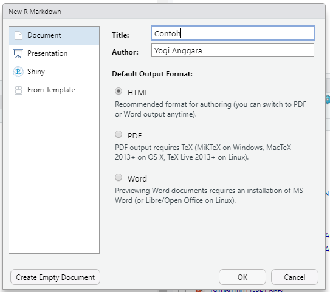

R Markdown sudah siap!

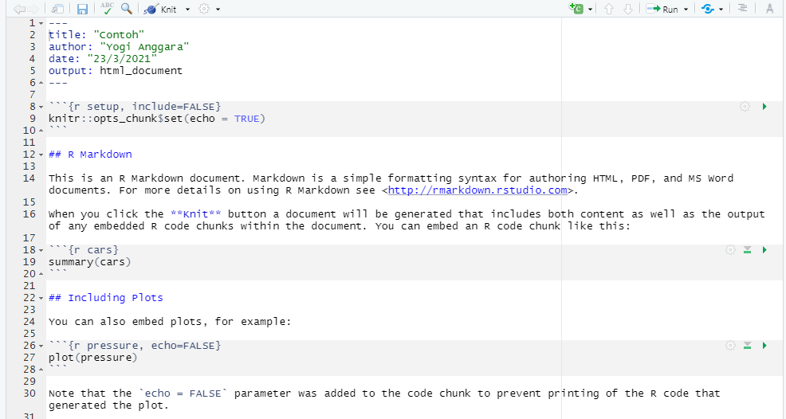

Untuk menyimpan filenya, silahkan klik `File > Save` atau dengan menekan `ctrrl + s`. Silahkan namai file dengan format `[Nama File].Rmd`

[figure not shown]

### 1.1.2 Penggunaan

Kelebihan dari R Markdown adalah dapat memadukan teks dan kode dalam satu file. Dengan demikina, R Markdown ini sangan berguna untuk membuat dokumen yang berisikan source code seperti **laporan praktikum**.

Untuk menambahkan potongan kode R, kita dapat mengklik ikon C berwarna hijau, lalu pilih R.

[figure not shown]

Untuk menuliskan kode, kalian bisa ketikan di daerah yang berwarna abu-abu. Untuk menjalankan potongan kode tersebut, kalian bisa klik ikon play berwarna hijau di sebelah kanan potongan kode. Untuk memasukan teks, kita cukup mengetiknya di daerah yang berwarna putih

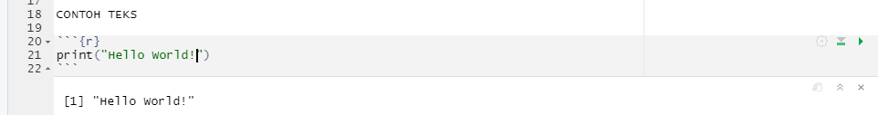

Jika kalian ingin menjalankan semua potongan kode dengan sekali klik, kalian bisa klik ikon run di bagian kanan atas, dan pilih `Run All`

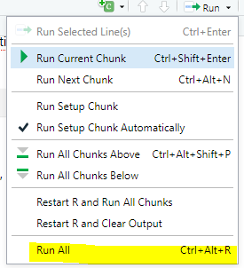

Untuk mengeksport R Markdown ke HTML, PDF, atau Word, kalian bisa klik ikon `Knit` di sebelah kiri atas.

[figure not shown]

Berikut adalah contoh jika dieksporrt ke HTML

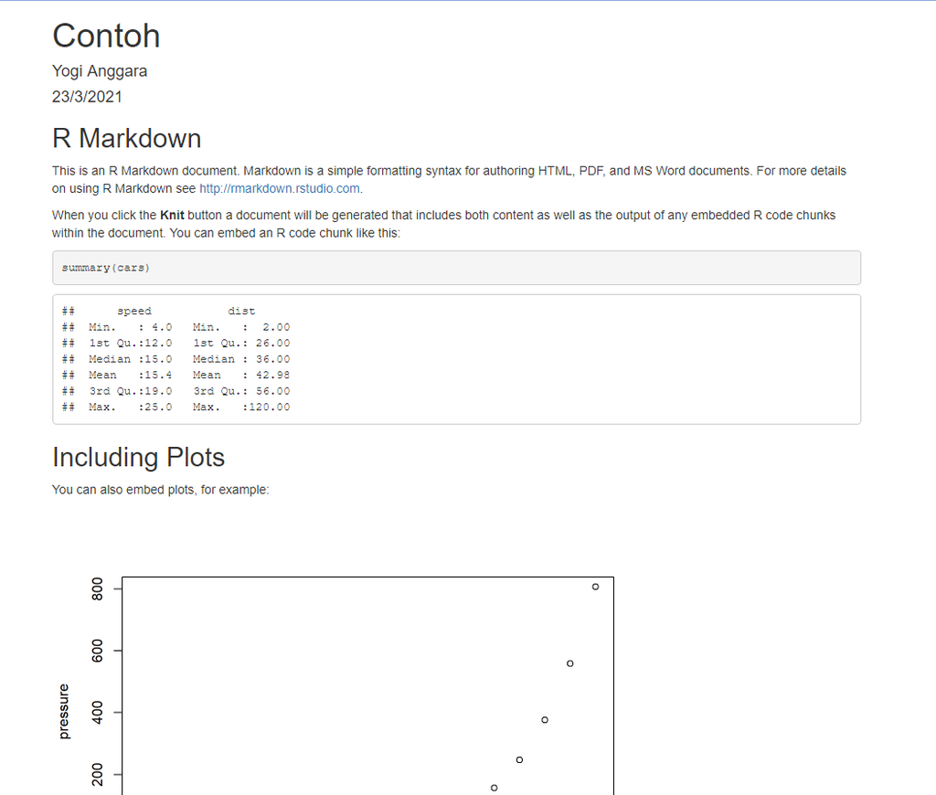

Masih banyak lagi fitur di R Markdown yang bisa kita eksplor lebih jauh. Untuk lebih dalam mengenai R Markdown, kalian bisa kunjungi:

- https://bookdown.org/yihui/rmarkdown/
- https://ourcodingclub.github.io/tutorials/rmarkdown/

## 1.2 Membuat Working Directory

Dalam komputasi, [Working Directory](https://en.wikipedia.org/wiki/Working_directory) dari suatu proses adalah direktori dari sistem file hierarki yang terkait secara dinamis dengan setiap proses. Sederhananya, ketika kita “mengimport” atau "mengeksport file ke kode kita, yang menjadi patokana awal adalah alamat dari direktori kerja. Untuk lebih jelasnya, mari langsung ke praktik. Silahkan buka `contoh.Rmd`

Sebelumnya WD berada pada `"E:/Kuliah/Semester 4/asprak metstat/materi/1"`

(Note: Lokasi file secara default akan menjadi alamat WD)

```r
getwd()
```

```
## [1] "E:/Kuliah/Semester 4/asprak metstat/materi/1"
```

Misalkan kita ingin mengambil data `diabetes.csv` di`E:\Kuliah\Semester 4\asprak metstat\materi\1\data\data2\data3\data4`

```r
df = read.csv("data/data2/data3/data4/diabetes.csv")
head(df)
```

|  | Pregnancies | Glucose | BloodPressure | SkinThickness | Insulin | BMI | DiabetesPedigreeFunction | Age | Outcome |
| --- | --- | --- | --- | --- | --- | --- | --- | --- | --- |
| 1 | 6 | 148 | 72 | 35 | 0 | 33.6 | 0.627 | 50 | 1 |
| 2 | 1 | 85 | 66 | 29 | 0 | 26.6 | 0.351 | 31 | 0 |
| 3 | 8 | 183 | 64 | 0 | 0 | 23.3 | 0.672 | 32 | 1 |
| 4 | 1 | 89 | 66 | 23 | 94 | 28.1 | 0.167 | 21 | 0 |
| 5 | 0 | 137 | 40 | 35 | 168 | 43.1 | 2.288 | 33 | 1 |
| 6 | 5 | 116 | 74 | 0 | 0 | 25.6 | 0.201 | 30 | 0 |

Lihat bahwa alamat direktori yang kita tuliskan sangat panjang. Kita dapat menyingkatnya dengan cara menjadikan `E:\Kuliah\Semester 4\asprak metstat\materi\1\data\data2\data3\data4` sebagai WD.

```r
setwd("data/data2/data3/data4/")
getwd()
```

```
## [1] "E:/Kuliah/Semester 4/asprak metstat/materi/1/data/data2/data3/data4"
```

```r
df = read.csv("diabetes.csv")
head(df)
```

|  | Pregnancies | Glucose | BloodPressure | SkinThickness | Insulin | BMI | DiabetesPedigreeFunction | Age | Outcome |
| --- | --- | --- | --- | --- | --- | --- | --- | --- | --- |
| 1 | 6 | 148 | 72 | 35 | 0 | 33.6 | 0.627 | 50 | 1 |
| 2 | 1 | 85 | 66 | 29 | 0 | 26.6 | 0.351 | 31 | 0 |
| 3 | 8 | 183 | 64 | 0 | 0 | 23.3 | 0.672 | 32 | 1 |
| 4 | 1 | 89 | 66 | 23 | 94 | 28.1 | 0.167 | 21 | 0 |
| 5 | 0 | 137 | 40 | 35 | 168 | 43.1 | 2.288 | 33 | 1 |
| 6 | 5 | 116 | 74 | 0 | 0 | 25.6 | 0.201 | 30 | 0 |

Alamat direktori yang kita masukan di `read.csv` menjadi lebih singkat, yeayy!!

Note: Jika kita hanya mengimport/eksport 1 file saja, sebaiknya tidak perlu merubah WD, di atas hanya contoh saja. WD akan sangat membantu jika kita menangani banyak file di satu direktori yang sama.

## 1.3 Cara Tahu Kegunaan Suatu Fungsi

Untuk mengetahui kegunaan dari suatu fungsi, bisa menggunakan `help(fungsi)` atau `?fungsi`

```r
# cara 1
help("read.csv")

# cara 2
?data.frame
```

Bisa juga langsung diakses dari R Studio (di kolom bawah kanan)

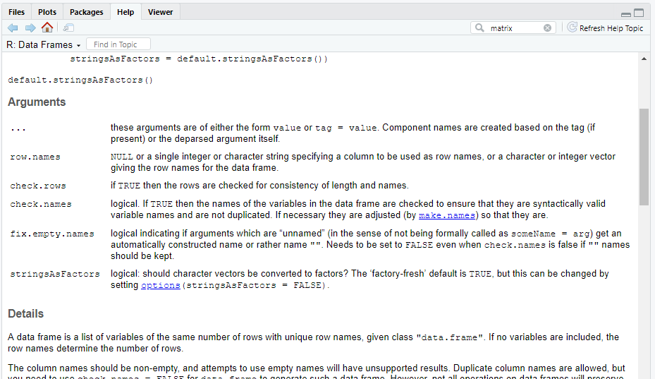